# MTH6139 Time Series

Coursework 1: Forecasting Global Interest in Formula 1

Pawandeep Bedi

March 2026

# Section 1: Introduction

This project analyses the popularity of the **Formula One World Championship** by using search data from Google Trends. The aim of this analysis is to explore patterns in interest over time and forecast future popularity using the Prophet model.

Formula 1 has grown in popularity significantly in recent years, partly due to increased media exposure. One major contributor to this rise is the release of the Netflix documentary series *Drive to Survive* in 2019, which takes a look at the behind the scenes action of the sport. More recently, the 2025 release of *F1 The Movie* has further increased mainstream attention of Formula 1, and the expansion of races in new locations, such as the debut of the upcoming *Madrid Grand Prix*, has meant that it’s reaching a wider global audience than ever before. This therefore provides an intriguing case for time series analysis, as changes in popularity for F1 are driven by a combination of sporting events and media influence!

## 1.1 Data Description

The dataset used in this analysis was taken from Google Trends and represents search interest for “Formula 1” globally over time. These data values are scaled and range from 0 to 100, where 100 represents peak popularity. The data is presented monthly, from January 2016 to January 2026.

Before any analysis was conducted, the dataset was cleaned and converted into a format compatible with Prophet using **R**, with *ds* representing dates and *y* representing search interest.

```r
# Loads the dataset
f1_trends_data <- read.csv("data/f1_trends_data.csv")

# Renames the columns for Prophet
colnames(f1_trends_data) <- c("ds", "y")

# Converts the columns into their correct formats
f1_trends_data$ds <- as.Date(f1_trends_data$ds, format = "%d/%m/%Y")
f1_trends_data$y <- as.numeric(f1_trends_data$y)
```

# Section 2: Exploratory Data Analysis

This section will initially explore the data for patterns and trends, as well as conduct a linear trend analysis to assess how well a simple linear model captures time series patterns for this data.

## 2.1 Time Series Plot

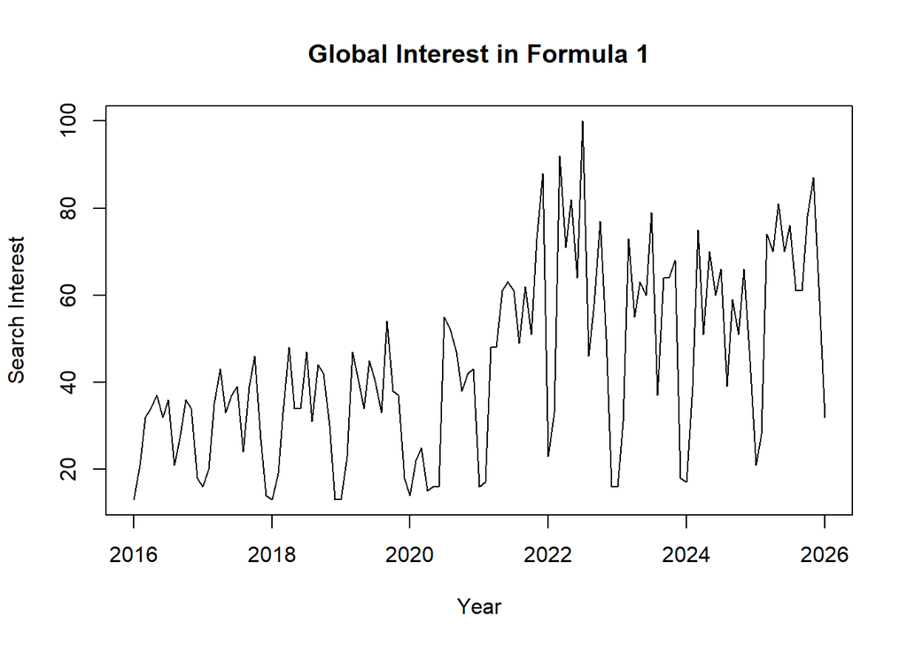

```r
# Plots Formula 1 interest over time
plot(f1_trends_data$ds, f1_trends_data$y, type = "l",
     main = "Global Interest in Formula 1",
     xlab = "Year", ylab = "Search Interest")
```

This plot shows a clear upward trend, suggesting an overall increase in popularity over time for Formula 1.

There is a noticeable increase in interest from 2021 onwards, with peak values occurring around the 2022 season. This is very likely due to the 2021 Formula 1 season featuring an exceptionally competitive championship battle between Lewis Hamilton and Max Verstappen, which went down to the very final race. This dramatic finale likely carried global interest into the 2022 season. The repeated peaks on the graph also indicate the presence of seasonality, likely corresponding to the Formula 1 racing calendar.

## 2.2 Linear Trend Analysis

```r
# Creates a time index (1, 2, 3, ..., n) to represent time progression
time_index <- 1:nrow(f1_trends_data)

# Fits a simple linear regression model to estimate the trend over time
lm_model <- lm(y ~ time_index, data = f1_trends_data)

# Displays summary statistics of the regression model
summary(lm_model)
```

```
##
## Call:
## lm(formula = y ~ time_index, data = f1_trends_data)
##
## Residuals:
##     Min      1Q  Median      3Q     Max
## -39.108 -10.902   2.238  10.087  49.949
##
## Coefficients:
##             Estimate Std. Error t value Pr(>|t|)
## (Intercept) 23.56653    3.18779   7.393 2.19e-11 ***
## time_index   0.33525    0.04535   7.392 2.20e-11 ***
## ---
## Signif. codes:  0 '***' 0.001 '**' 0.01 '*' 0.05 '.' 0.1 ' ' 1
##
## Residual standard error: 17.42 on 119 degrees of freedom
## Multiple R-squared:  0.3147, Adjusted R-squared:  0.3089
## F-statistic: 54.65 on 1 and 119 DF,  p-value: 2.196e-11
```

There is a statistically significant positive relationship between time and search interest in Formula 1. On average, search interest increases by roughly 0.335 units per month and approximately 31.47% of the variation in search interest can be explained by its linear trend. This is further supported by the residuals which suggests that factors such as seasonal patterns and short-term fluctuations affect search interest.

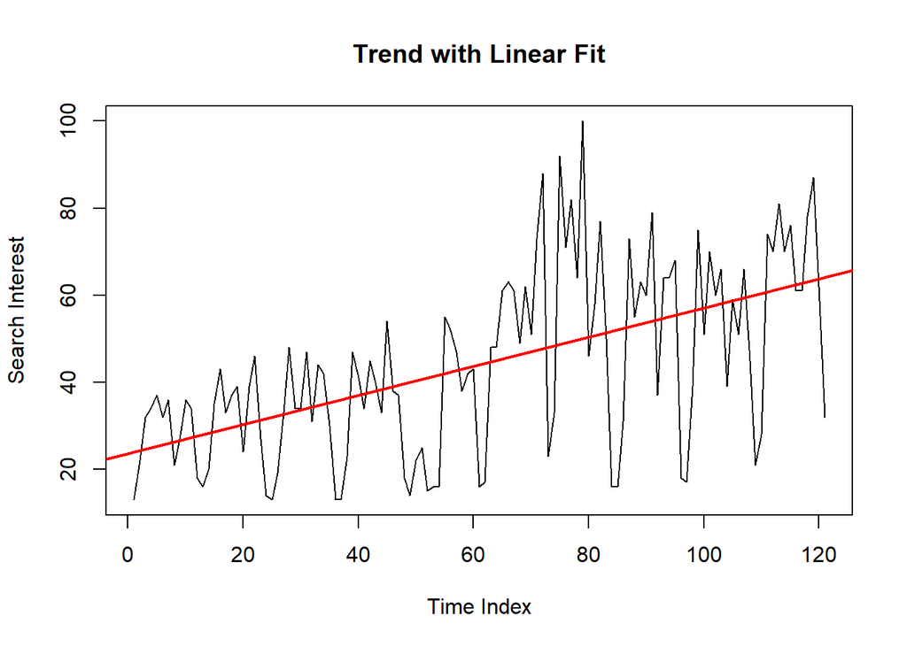

```r
# Plots using time index
plot(time_index, f1_trends_data$y, type = "l",
     main = "Trend with Linear Fit",
     xlab = "Time Index", ylab = "Search Interest")

# Adds a regression line
abline(lm_model, col = "red", lwd = 2)
```

This linear model supports the observations from the initial time series plot as the red line representing the overall trend in the data is evidently upwards-sloping. However, this does not fully capture the structure of the time series, so Prophet will be used to model both the underlying trend and seasonal patterns more effectively.

# Section 3: Forecasting with Prophet

This section will explore the application of the Prophet library and its application to the Formula 1 dataset. The model will be used to generate forecasts of future search interest for the next two years.

## 3.1 Fitting a Model

```r
# Loads the Prophet package
library(prophet)

# Fits the Prophet model to the data
model_f1 <- prophet(f1_trends_data)
```

## 3.2 Creating Future Data

```r
# Creates future dates (2 years ahead)
future_f1 <- make_future_dataframe(model_f1, periods = 24, freq = "month")
```

## 3.3 Generating a Forecast

```r
# Generates forecast values
forecast_f1 <- predict(model_f1, future_f1)
```

## 3.4 Results from Forecasting

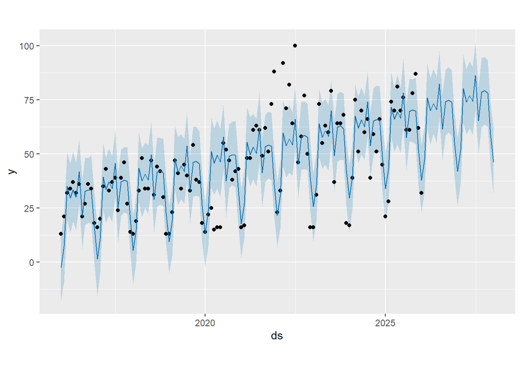

```r
# Plots forecast results
plot(model_f1, forecast_f1)
```

In this Prophet forecast plot, the black points represent the search interest data, the blue line represents the model’s fitted and predicted values, and the shaded region represents the uncertainty interval.

## 3.5 Forecast Components

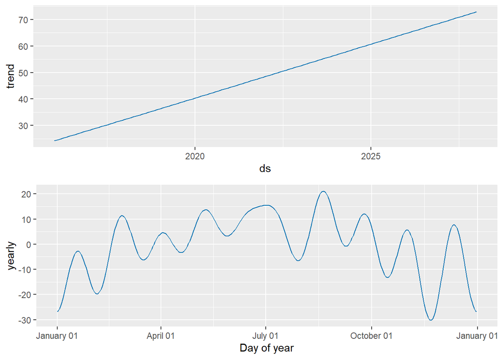

```r
# Plots trend and seasonality components
prophet_plot_components(model_f1, forecast_f1)
```

The output for the Prophet component plots decomposes the time series into its underlying trend and seasonal components.

The bottom graph for the yearly seasonality component indicates that there is a clear recurring pattern within each year. Periods with positive values indicate times when the search interest is above average, while negative values represent the opposite. Overall, interest in Formula 1 follows a predictable cyclical pattern.

# Section 4: Conclusion

Overall, this analysis showed that the growth in popularity in Formula 1 has been steady, with strong seasonal fluctuations that closely align with its racing calendar. The sport’s growing digital presence has made it more accessible to a broader audience, and the rise of more globally recognisable drivers and teams has also contributed to its growing global fan base.

From a modelling perspective, the initial linear regression analysis lacked the capability of capturing the full complexity of the F1 data whereas the Prophet model accounted for both trend and seasonality, creating more realistic forecasts. The Prophet model predicts that interest in Formula 1 will continue to grow in a similar manner over the next two years, continuing its recurring cyclical patterns.

However, future popularity may be influenced by unpredictable factors. The current 2026 season so far has incorporated major regulation changes, including significant new required technological developments to the design and performance of their racing cars. While this may attract new audiences, this may deter and risk alienating existing fans who prefer the previous structure and style of racing.

# References

- Google Trends reference: https://trends.google.com/explore?q=%2Fm%2F02xz2&date=2016-01-01%202026-01-01&geo=Worldwide
- RStudio reference: https://rmarkdown.rstudio.com/lesson-1.html
- RMarkdown reference: https://bookdown.org/yihui/rmarkdown/